## Project: Influence of news media on stock

```
        by Amara Midouhas and Rehan Mullan
```

# Collaboration Plan:

Our goal is to answer the question, " How has AI in the media impacted technology stocks?"

The news plays a major role in shaping reader's perceptions. With AI becoming a popular area of discussion, authors have unitentionally displayed either their pessimism or optimism about AI. Is this bias affecting how readers are viewing technology companies ? In more depth, is the demand for stock in technology companies increasing or decreasing in accordance to media's perspective of AI?

We are using LiveShare for VSCode and met everyday for the past week for a couple of hours to work on the tutorial together. We are going to be using python libraries such as pandas, matplotlib, seaborn and jupyter labs as tools to help us complete this analysis. We worked on tidying the datasets togther, though Rehan did most of the graphs and Amara wrote most of the tutorial. So far in our analysis, we believe that the datasets we do have (The New York times sentiment analysis and the S&P 500 companies - Facebook, Amazon, AMD, Microsoft, and IBM) will support us in our analysis. The S&P 500 companies dataset does not include Google nor Tesla, so we want to include a historical stock dataset of Google and Tesla.

# Dataset 1: Sentiment Analysis of the New York Times (https://msropendata.com/datasets/feed8996-d9d4-47b9-9938-44ed298628fc)

This dataset from Microsoft contains multiple articles for over 20 years. We believe this dataset is appropriate for our analysis because the New York Times is one of the most popular newspapers read in the United States. Therefore, their perceptions play a major role in any major topic. The dataset includes the common words associated with AI like "Cyborg", "Singularity", and "Healthcare." These words and more are placed into a negative or positive column to judge the use of it. Additionally, there are columns of the date and time of when the article was published, it's section, title, and where AI was mentioned in the article. It also includes how revelant AI was to the article and the author's mood about it with a score of 5 being the highest. We believe this dataset is appropriate for our analysis because the New York Times is one of the most popular newspapers read in the world. Therefore, their perceptions play a major role in people's outlooks on certain topics.

```python
# Read in the media's perception of AI dataset
import pandas as pd
perceptions_AI = pd.read_csv("robot-ai-all-public.csv")
perceptions_AI
```

|  | Article ID | Article Date | Paragraph number | NYT section | Paragraph | Title | WorkTimeInSeconds | AI Mood | AI Relevance | Fiction | ... | Other (negative) | Cyborg (positive) | Decisions (positive) | Education (positive) | Entertain (positive) | Healthcare (positive) | Singularity (positive) | Transportation (positive) | Work (positive) | Other (positive) |
| --- | --- | --- | --- | --- | --- | --- | --- | --- | --- | --- | --- | --- | --- | --- | --- | --- | --- | --- | --- | --- | --- |
| 0 | 4fd1cbc98eb7c8105d701286 | 1996-10-06 00:00:00 UTC | 18 | New York and Region | Thus, next weekend will feature the robot who ... | LONG ISLAND JOURNAL | 1472 | 4 | 5 | 0 | ... | {} | 0 | 0 | 0 | 0 | 0 | 0 | 0 | 0 | {} |
| 1 | 4fd1cbc98eb7c8105d701286 | 1996-10-06 00:00:00 UTC | 18 | New York and Region | Thus, next weekend will feature the robot who ... | LONG ISLAND JOURNAL | 49 | 4 | 5 | 0 | ... | {} | 0 | 0 | 0 | 0 | 0 | 0 | 0 | 0 | {} |
| 2 | 4fd1cbc98eb7c8105d701286 | 1996-10-06 00:00:00 UTC | 18 | New York and Region | Thus, next weekend will feature the robot who ... | LONG ISLAND JOURNAL | 66 | 5 | 5 | 0 | ... | {} | 0 | 0 | 0 | 1 | 0 | 0 | 0 | 0 | {} |
| 3 | 54b0793b7988100e21965770 | 2006-07-31 00:00:00 UTC | 16 | Technology | That phrase was coined in the 1970۪s by Masahi... | Camera System Creates Sophisticated 3-D Effects | 3053 | 3 | 4 | 0 | ... | {} | 0 | 0 | 0 | 0 | 0 | 0 | 0 | 0 | {} |
| 4 | 54b0793b7988100e21965770 | 2006-07-31 00:00:00 UTC | 16 | Technology | That phrase was coined in the 1970۪s by Masahi... | Camera System Creates Sophisticated 3-D Effects | 25 | 3 | 4 | 0 | ... | {} | 0 | 0 | 0 | 0 | 0 | 0 | 0 | 0 | {} |
| ... | ... | ... | ... | ... | ... | ... | ... | ... | ... | ... | ... | ... | ... | ... | ... | ... | ... | ... | ... | ... | ... |
| 17068 | 566b44b87988100e80618c8f | 2015-12-12 00:00:00 UTC | 23 | Science | Also in 2014, the Microsoft A.I. researcher Er... | Artificial-Intelligence Research Center Is Fou... | 47 | 3 | 3 | 0 | ... | {} | 0 | 0 | 0 | 0 | 0 | 0 | 0 | 0 | {} |
| 17069 | 566b44b87988100e80618c8f | 2015-12-12 00:00:00 UTC | 23 | Science | Also in 2014, the Microsoft A.I. researcher Er... | Artificial-Intelligence Research Center Is Fou... | 378 | 3 | 2 | 0 | ... | {} | 0 | 0 | 0 | 0 | 0 | 0 | 0 | 0 | {} |
| 17070 | 566e112d79881065df1e156e | 2015-12-14 00:00:00 UTC | 8 | Business Day | The decision about the station rests with the ... | Howard University May Sell Rights to Its Publi... | 28 | 3 | 1 | 0 | ... | {} | 0 | 0 | 0 | 0 | 0 | 0 | 0 | 0 | {} |
| 17071 | 566e112d79881065df1e156e | 2015-12-14 00:00:00 UTC | 8 | Business Day | The decision about the station rests with the ... | Howard University May Sell Rights to Its Publi... | 331 | 3 | 1 | 0 | ... | {} | 0 | 0 | 0 | 0 | 0 | 0 | 0 | 0 | {} |
| 17072 | 566e112d79881065df1e156e | 2015-12-14 00:00:00 UTC | 8 | Business Day | The decision about the station rests with the ... | Howard University May Sell Rights to Its Publi... | 240 | 3 | 1 | 0 | ... | {} | 0 | 0 | 0 | 0 | 0 | 0 | 0 | 0 | {} |

17073 rows × 27 columns

```python
# We will clean the data
# Change the Article Date column
s = perceptions_AI["Article Date"].str.split(" ",n = 3,expand=True)
#This will show just the data
perceptions_AI["Date"] = s[0]
perceptions_AI["Date"]

# These are the columns we deleted
#del perceptions_AI["Article ID"]
#del perceptions_AI["Article Date"]
#del perceptions_AI["Paragraph number"]
#del perceptions_AI["WorkTimeInSeconds"]
```

We made sure that we knew each of the data types in our data by calling upon dtypes before we began our graph.

```python
perceptions_AI.dtypes
```

```
Article ID                   object
Article Date                 object
Paragraph number             object
NYT section                  object
Paragraph                    object
Title                        object
WorkTimeInSeconds             int64
AI Mood                       int64
AI Relevance                  int64
Fiction                       int64
Controling AI (negative)      int64
Cyborg (negative)             int64
Ethics (negative)             int64
Military (negative)           int64
Progress (negative)           int64
Singularity (negative)        int64
Work (negative)               int64
Other (negative)             object
Cyborg (positive)             int64
Decisions (positive)          int64
Education (positive)          int64
Entertain (positive)          int64
Healthcare (positive)         int64
Singularity (positive)        int64
Transportation (positive)     int64
Work (positive)               int64
Other (positive)             object
Date                         object
dtype: object
```

Here we realized that a lot of our data contained NAN values. To get rid of those, we had to drop all rows containing NAN, which reduced our data signinficantly. Though we still had plenty of data to work with.

```python
##multiple values in same bin messing up our graphs: want to take the average of the sentiment


perceptions_AI = perceptions_AI.dropna().reset_index(drop=True)


#sorting the data

# This allowed to move the Date column to the front
#cols = perceptions_AI.columns.tolist()
#cols = cols[-1:] + cols[:-1]
#perceptions_AI = perceptions_AI[cols]
```

[output not shown]

**How has the perceptions of AI changed overtime?**

```python
# We used seaborn because it makes the graph look better
import seaborn as sns
import matplotlib.pyplot as plt
sns.set_style("darkgrid")

#We want add up the amount of AI moods per the date, which is technically the AI moods per the title
# The higher the amount means a positive outlook on AI
# A low amount means a negative outlook on AI
perceptions_AI.groupby("Date")["AI Mood"].sum()
```

```
Date
1986-01-03      9
1986-01-05     12
1986-01-16      9
1986-01-26     19
1986-01-30      9
             ...
2016-04-13     20
2016-04-19      9
2016-04-24     24
2016-04-28    131
2016-04-30      8
Name: AI Mood, Length: 1623, dtype: int64
```

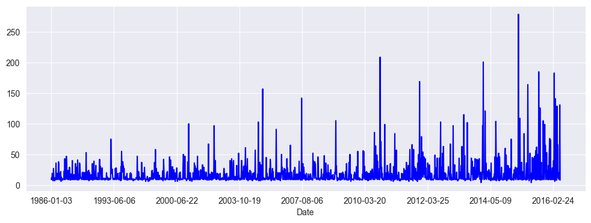

```python
perceptions_AI.groupby("Date")["AI Mood"].sum().plot(figsize=(12,4),color="blue")
```

# Dataset 2: S&P 500 historical data (https://datahub.io/core/s-and-p-500-companies#resource-s-and-p-500-companies_zip)

For right now, we are using the Apple dataset from the S&P 500 dataset

```python
#Read in data set
apple = pd.read_csv("AAPL.csv")
apple.head()
# Our data is very tidy so we did not need to fix it.
```

|  | Date | High | Low | Open | Close | Volume | Adj Close |
| --- | --- | --- | --- | --- | --- | --- | --- |
| 0 | 2006-01-03 | 2.669643 | 2.580357 | 2.585000 | 2.669643 | 807234400.0 | 2.284267 |
| 1 | 2006-01-04 | 2.713571 | 2.660714 | 2.683214 | 2.677500 | 619603600.0 | 2.290990 |
| 2 | 2006-01-05 | 2.675000 | 2.633929 | 2.672500 | 2.656429 | 449422400.0 | 2.272961 |
| 3 | 2006-01-06 | 2.739286 | 2.662500 | 2.687500 | 2.725000 | 704457600.0 | 2.331634 |
| 4 | 2006-01-09 | 2.757143 | 2.705000 | 2.740357 | 2.716071 | 675040800.0 | 2.323994 |

We want the means of highs and lows of Apple. This will allow us to see the average price of the stock per the date.

```python
apple.describe()
```

|  | High | Low | Open | Close | Volume | Adj Close |
| --- | --- | --- | --- | --- | --- | --- |
| count | 3749.000000 | 3749.000000 | 3749.000000 | 3749.000000 | 3.749000e+03 | 3749.000000 |
| mean | 25.474194 | 24.939415 | 25.209072 | 25.216799 | 4.483879e+08 | 23.669295 |
| std | 23.634906 | 23.043211 | 23.342469 | 23.352043 | 3.973082e+08 | 23.341147 |
| min | 1.888929 | 1.791429 | 1.847500 | 1.809643 | 2.043060e+07 | 1.548412 |
| 25% | 6.857143 | 6.707857 | 6.790000 | 6.783928 | 1.440128e+08 | 5.804637 |
| 50% | 19.645357 | 19.242857 | 19.482143 | 19.445000 | 3.262924e+08 | 17.087896 |
| 75% | 34.912498 | 34.650002 | 34.712502 | 34.750000 | 6.327160e+08 | 32.785446 |
| max | 137.979996 | 130.529999 | 137.589996 | 134.179993 | 3.372970e+09 | 133.948898 |

```python
#New Column called mean
apple["mean"] = (apple["High"] + apple["Low"]) //2
apple["mean"]
```

```
0         2.0
1         2.0
2         2.0
3         2.0
4         2.0
        ...
3744    119.0
3745    119.0
3746    118.0
3747    117.0
3748    118.0
Name: mean, Length: 3749, dtype: float64
```

**How has the stock price of a technology company (Apple) changed overtime ?**

After plotting, we could see the general trend of the Apple stock. It has risen exponentially, especially in recent years.

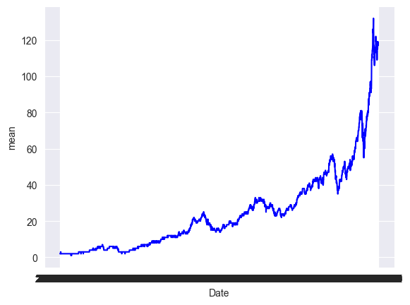

```python
#Using seaborn to plot because it looks better
sns.lineplot(data=apple,x = "Date",y = "mean",color="blue")
```

```python
%%shell
jupyter nbconvert --to html /content/drive/MyDrive/Colab\ Notebooks/Milestone.ipynb
```

```
[NbConvertApp] Converting notebook /content/drive/MyDrive/Colab Notebooks/Milestone.ipynb to html
[NbConvertApp] Writing 402077 bytes to /content/drive/MyDrive/Colab Notebooks/Milestone.html
```

```python
from google.colab import drive
drive.mount('/content/drive')

#Milestone.ipynb
```

```python
!pwd
```

```
/content/drive/MyDrive/Colab Notebooks
```